# Coursera Practical Machine Learning

*Ousmane Souleymane*  
*June 07, 2016*

## Introduction

The objective of this analysis is to attempt to identify the type of exercise when using device such as Jawbone Up, Nike FuelBand and FitBit.  
The required data for the processing are collected from motion sensors placed on 6 participants. The accelerometers were placed on the arm, forearm, belt and dumbell.

## Data processing

For the analysis we need some R packages as indicated in the code.  
The training dataset contain 19622 rows of data with 160 variables and the testing dataset contain 20 observations.

```r
# Required R packages
library(caret)
library(rattle)
```

```r
library(rpart)
library(rpart.plot)
library(randomForest)
library(repmis)
```

```r
# Load the dataset
training <- read.csv("pml-training.csv", na.strings = c("NA", ""))
testing <- read.csv("pml-testing.csv", na.strings = c("NA", ""))
```

## Data cleaning

We have note that many variables contained a lot of missing value so they were removed from the dataset.

```r
# Delete colums with missing values
training <- training[, colSums(is.na(training)) == 0]
testing <- testing[, colSums(is.na(testing)) == 0]
```

```r
# Remove some predictors
trainData <- training[, -c(1:7)]
testData <- testing[, -c(1:7)]
```

## Data splitting

The dataset was partitioned into training and testing with 70% going for training and 30% for the testing.

```r
# Data splitting
set.seed(7826)
inTrain <- createDataPartition(trainData$classe, p = 0.7, list = FALSE)
train <- trainData[inTrain, ]
valid <- trainData[-inTrain, ]
```

## Model

Many test were conducted with some classification method (multinomial logistic regression, niave Bayes, decision trees, etc). The decision trees and random forest method produced the best result to predict the model.

```r
# Classification trees
control <- trainControl(method = "cv", number = 5)
fit_rpart <- train(classe ~ ., data = train, method = "rpart",
                   trControl = control)
print(fit_rpart, digits = 4)
```

```
## CART
##
## 13737 samples
##    52 predictor
##     5 classes: 'A', 'B', 'C', 'D', 'E'
##
## No pre-processing
## Resampling: Cross-Validated (5 fold)
## Summary of sample sizes: 10989, 10989, 10990, 10989, 10991
## Resampling results across tuning parameters:
##
##   cp       Accuracy  Kappa
##   0.03723  0.5241    0.38748
##   0.05954  0.4144    0.20668
##   0.11423  0.3482    0.09762
##
## Accuracy was used to select the optimal model using  the largest value.
## The final value used for the model was cp = 0.03723.
```

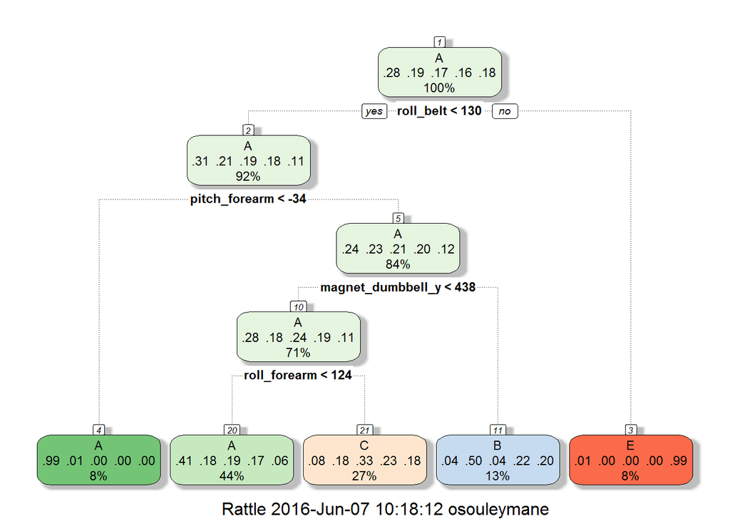

```r
fancyRpartPlot(fit_rpart$finalModel)
```

## Decision trees

```r
# predict outcomes using validation set
predict_rpart <- predict(fit_rpart, valid)
# Show prediction result
(conf_rpart <- confusionMatrix(valid$classe, predict_rpart))
```

```
## Confusion Matrix and Statistics
##
##           Reference
## Prediction    A    B    C    D    E
##          A 1544   21  107    0    2
##          B  492  391  256    0    0
##          C  474   38  514    0    0
##          D  436  175  353    0    0
##          E  155  138  293    0  496
##
## Overall Statistics
##
##                Accuracy : 0.5004
##                  95% CI : (0.4876, 0.5133)
##     No Information Rate : 0.5269
##     P-Value [Acc > NIR] : 1
##
##                   Kappa : 0.3464
##  Mcnemar's Test P-Value : NA
##
## Statistics by Class:
##
##                      Class: A Class: B Class: C Class: D Class: E
## Sensitivity            0.4979  0.51245  0.33749       NA  0.99598
## Specificity            0.9533  0.85396  0.88262   0.8362  0.89122
## Pos Pred Value         0.9223  0.34328  0.50097       NA  0.45841
## Neg Pred Value         0.6303  0.92162  0.79234       NA  0.99958
## Prevalence             0.5269  0.12965  0.25879   0.0000  0.08462
## Detection Rate         0.2624  0.06644  0.08734   0.0000  0.08428
## Detection Prevalence   0.2845  0.19354  0.17434   0.1638  0.18386
## Balanced Accuracy      0.7256  0.68321  0.61006       NA  0.94360
```

```r
(accuracy_rpart <- conf_rpart$overall[1])
```

```
##  Accuracy
## 0.5004248
```

## Random forest

The accuracy rate generate by the random forest model is 0.991, so no additional cross validation is necessary.

```r
fit_rf <- train(classe ~ ., data = train, method = "rf",
                   trControl = control)
print(fit_rf, digits = 4)
```

```
## Random Forest
##
## 13737 samples
##    52 predictor
##     5 classes: 'A', 'B', 'C', 'D', 'E'
##
## No pre-processing
## Resampling: Cross-Validated (5 fold)
## Summary of sample sizes: 10990, 10990, 10990, 10988, 10990
## Resampling results across tuning parameters:
##
##   mtry  Accuracy  Kappa
##    2    0.9903    0.9878
##   27    0.9909    0.9885
##   52    0.9851    0.9812
##
## Accuracy was used to select the optimal model using  the largest value.
## The final value used for the model was mtry = 27.
```

```r
# predict outcomes using validation set
predict_rf <- predict(fit_rf, valid)
# Show prediction result
(conf_rf <- confusionMatrix(valid$classe, predict_rf))
```

```
## Confusion Matrix and Statistics
##
##           Reference
## Prediction    A    B    C    D    E
##          A 1669    3    0    0    2
##          B    8 1128    2    1    0
##          C    0    2 1017    7    0
##          D    0    1   14  945    4
##          E    0    1    1    4 1076
##
## Overall Statistics
##
##                Accuracy : 0.9915
##                  95% CI : (0.9888, 0.9937)
##     No Information Rate : 0.285
##     P-Value [Acc > NIR] : < 2.2e-16
##
##                   Kappa : 0.9893
##  Mcnemar's Test P-Value : NA
##
## Statistics by Class:
##
##                      Class: A Class: B Class: C Class: D Class: E
## Sensitivity            0.9952   0.9938   0.9836   0.9875   0.9945
## Specificity            0.9988   0.9977   0.9981   0.9961   0.9988
## Pos Pred Value         0.9970   0.9903   0.9912   0.9803   0.9945
## Neg Pred Value         0.9981   0.9985   0.9965   0.9976   0.9988
## Prevalence             0.2850   0.1929   0.1757   0.1626   0.1839
## Detection Rate         0.2836   0.1917   0.1728   0.1606   0.1828
## Detection Prevalence   0.2845   0.1935   0.1743   0.1638   0.1839
## Balanced Accuracy      0.9970   0.9958   0.9909   0.9918   0.9966
```

```r
(accuracy_rf <- conf_rf$overall[1])
```

```
##  Accuracy
## 0.9915038
```

## Conclusion

The random forest is well suited for the generating accurate prediction for this dataset. Complete the course, we use this method to predict the outcome variable classe for the 20 tests cases.

```r
(predict(fit_rf, testData))
```

```
##  [1] B A B A A E D B A A B C B A E E A B B B
## Levels: A B C D E
```